# R Notebook

# save as .RData

Loading data from a RData file, that is smaller in size than the original csv files

```r
load("data/movielens.RData")
```

Loading necessary libraries

```r
library(tidyverse)
library(NNLM)
library(tictoc)
```

Looking at the data

```r
glimpse(ratings)
```

```
Observations: 27,753,444
Variables: 4
$ userId    <int> 1, 1, 1, 1, 1, 1, 1, 1, 1, 1, 1, 1, 1, 1, 1, 1, 2, 2, 2, 2, 2, 2, 2, 2, 2, 2, 2, 2, 2, 2, 2, 3, 3, 3, 3, 3, 3, 3, 3, 3...
$ movieId   <int> 307, 481, 1091, 1257, 1449, 1590, 1591, 2134, 2478, 2840, 2986, 3020, 3424, 3698, 3826, 3893, 170, 849, 1186, 1235, 12...
$ rating    <dbl> 3.5, 3.5, 1.5, 4.5, 4.5, 2.5, 1.5, 4.5, 4.0, 3.0, 2.5, 4.0, 4.5, 3.5, 2.0, 3.5, 3.5, 3.5, 3.5, 3.0, 3.0, 4.5, 3.0, 4.0...
$ timestamp <int> 1256677221, 1256677456, 1256677471, 1256677460, 1256677264, 1256677236, 1256677475, 1256677464, 1256677239, 1256677500...
```

Looking at the data contd.

```r
length(unique(ratings$userId))
```

```
[1] 283228
```

```r
unique(ratings$rating)
```

```
 [1] 3.5 1.5 4.5 2.5 4.0 3.0 2.0 5.0 1.0 0.5
```

```r
length(unique(movies$movieId))
```

```
[1] 58098
```

```r
length(unique(movies$title))
```

```
[1] 58020
```

From the length of the unique “movieId” and “title” above, we see that some titles are associated with more than one movieId. There are 78 such duplicates, It was decided that the duplicates would be removed. This is executed in the chuck below.

```r
movies <- distinct(movies, title, .keep_all = T)
```

Creating a more detailed Ratings dataset, by including movie title and genre

| userId | movieId | rating | timestamp | title | genres |
| --- | --- | --- | --- | --- | --- |
| 1 | 307 | 3.5 | 1256677221 | Three Colors: Blue (Trois couleurs: Bleu) (1993) | Drama |
| 1 | 481 | 3.5 | 1256677456 | Kalifornia (1993) | Drama\|Thriller |
| 1 | 1091 | 1.5 | 1256677471 | Weekend at Bernie's (1989) | Comedy |
| 1 | 1257 | 4.5 | 1256677460 | Better Off Dead... (1985) | Comedy\|Romance |
| 1 | 1449 | 4.5 | 1256677264 | Waiting for Guffman (1996) | Comedy |
| 1 | 1590 | 2.5 | 1256677236 | Event Horizon (1997) | Horror\|Sci-Fi\|Thriller |
| 1 | 1591 | 1.5 | 1256677475 | Spawn (1997) | Action\|Adventure\|Sci-Fi\|Thriller |
| 1 | 2134 | 4.5 | 1256677464 | Weird Science (1985) | Comedy\|Fantasy\|Sci-Fi |
| 1 | 2478 | 4.0 | 1256677239 | Â¡Three Amigos! (1986) | Comedy\|Western |
| 1 | 2840 | 3.0 | 1256677500 | Stigmata (1999) | Drama\|Thriller |

[output cut: 990 more lines]

This functions creates a subset of the movie dataset, using the required number of users and movies, and a specified seed for replication.

```r
Data_Subset <- function(data, no_of_users, no_of_movies, seed){
  #data - the dataframe of the movie ratings
  #no_of_users - scalar value, the number of users to be sampled at random from the full dataset
  #no_of_movies - scalar value, the number of movies to sample. The movies shall be sampled in descending order to gain as much information as possible
  #seed - the set seed needed for reproducing results.

  #movies_frq is the total number of ratings for each movie received, arranging in descending order to capture the top rated movies for the subset
  movies_frq <- data %>% group_by(movieId) %>% summarize(count = n()) %>% arrange(desc(count))
  Movies <- movies_frq$movieId[1:no_of_movies]

  #users_frq is the total number of ratings for each user gave, which will be sampled randomly according to the specified seed.
  users_frq <- data %>% group_by(userId) %>% summarize(count = n()) %>% arrange(desc(count))
  set.seed(seed)
  Users <- sample_n(users_frq, size = no_of_users, replace = F) %>% select(userId)


  Data_SubSet <- data %>% filter(userId %in% (Users$userId), movieId %in% Movies) %>% droplevels()
  return(Data_SubSet)
}
```

Cosine similarity function

```r
tic("Cosine_Sim1")
cosine_sim <- function(a){
  #a - the matrix on which cosine similarity will be performed on.
  #b - the output matrix of the cosine similarity function

  a <- ifelse(is.na(a), 0, a)
  b <- tcrossprod(a/sqrt(rowSums(a^2)))
  diag(b) <- 0
  row.names(b) <- row.names(a) #copying the names from the original matrix to label the new matrix
  colnames(b) <- row.names(a)

  return(as.matrix(b))
}

toc()
```

```
Cosine_Sim1: 0.09 sec elapsed
```

User-based and by extension item based prediction process. This is specifically to predict the ratings for the values in the test set to calculate the RMSE

```r
  UB_predicted <- NULL

  for (i in 1:length(test$userId)){
    user <- as.character(test$userId[i])   #selecting the user from the test set to predict rating for
    title <- as.character(test$title[i])   #selecting the corresponding movie from the test set
    sim <- user_sim[user,]      #the selected user's similarity vector
    rate <- Movie_rating[,title]   #the ratings for the corresponding movie

    #sim_to_user then combines the similarity vector and the available ratings, while omitting all users who haven't rated the movie
    sim_to_user <- as.data.frame(na.omit(cbind(sim, rate)))
    scaled_sim <- sim_to_user$sim/sum(sim_to_user$sim)   #this scales the similarity values to sum up to 1.
    sim_to_user <- cbind(sim_to_user,scaled_sim)

    #multiplying the ratings and the scaled similarity values gives a rating prediction between 1 and 5
    UB_predicted[i] <- crossprod(sim_to_user$rate,scaled_sim)

    #In the event, that a user is not similar to any of the users who have rated the movie, the average rating from the other users is given
    UB_predicted[i] <- ifelse(is.nan(UB_predicted[i]) == T, mean(sim_to_user$rate), UB_predicted[i])
  }
```

#Matrix Factorization with bias and Regularisation

```r
MF_TestPrediction <- function(Movie_rating, test){
  #H0 and W0 are the bias matrices, that are set to an initial value of 1.
init = list(
  H0 = matrix(1, nrow = 1, ncol = ncol(Movie_rating)),
  W0 = matrix(1, nrow = nrow(Movie_rating), ncol = 1)
)

# matrix factorization with bias included
decomp <- nnmf(A = Movie_rating,
               method = "scd",
               k = 3,
               alpha = c(0.001,0,0),  #L2 Regularisation on W
               beta = c(0.001,0,0),   #L2 Regularisation on H
               init = init, # bias terms
               max.iter = 10000) #Maximum number of iterations

# results
mf_observed <- decomp$W %*% decomp$H  #predicted values of all the movie & user combinations

#This function extracts the predictions of the test set observations.
Prediction <- function(i){
  user <- as.character(test$userId[i])
  title <- as.character(test$title[i])
  Predicted <- NULL

  Predicted[i] <- mf_observed[user, title]
  Predicted[i] <- ifelse(Predicted[i] < 1, 1, Predicted[i]) #if the prediction is less than 1, if should be limited to 1
  Predicted[i] <- ifelse(Predicted[i] > 5 , 5, Predicted[i]) #if the prediction is greater than 5, if should be limited to 5
}


r = nrow(test)
MF_Predicted <- sapply(1:r, Prediction)  #this runs multiple values through the prediction function


return(MF_Predicted)
}
```

Fulltest is the function created to run all three prediction methods, combine them to attain an ensembled result, and only output the final RMSE.

NB: the model predicting the all movie ratings for all users, can be found at the end of this file.

```r
Fulltest <- function(seed, no_of_users, data, no_of_movies){
  Reduced_Ratings <- Data_Subset(data, no_of_users, no_of_movies, seed)

  set.seed(seed) #USing the same seed for all iterations
  testobs <- sample(nrow(Reduced_Ratings),trunc(length(Reduced_Ratings$rating)*0.1)) #sampling 10% of points to form the test set

  test <- Reduced_Ratings[testobs,]  #saving the test set and its values

  Reduced_Ratings$rating[testobs] <- NA  # setting them to NA for the model to predict

  Movie_rating <- Reduced_Ratings %>%
    complete(userId, title) %>%
    select(userId, title, rating) %>%
    spread(key = title, value = rating)

  sorted_users <- as.character(unlist(Movie_rating[,1]))
  Movie_rating <- as.matrix(Movie_rating[,-1])
  row.names(Movie_rating) <- sorted_users

  user_sim <- cosine_sim(Movie_rating)

  predictedA <- NULL

  for (i in 1:length(test$userId)){
    user <- as.character(test$userId[i])
    title <- as.character(test$title[i])
    sim <- user_sim[user,]
    rate <- Movie_rating[,title]

    sim_to_user <- as.data.frame(na.omit(cbind(sim, rate)))
    scaled_sim <- sim_to_user$sim/sum(sim_to_user$sim)
    sim_to_user <- cbind(sim_to_user,scaled_sim)
    predictedA[i] <- crossprod(sim_to_user$rate,scaled_sim)
    predictedA[i] <- ifelse(is.nan(predictedA[i]) == T, mean(sim_to_user$rate), predictedA[i])
  }

  movies_user <- t(Movie_rating)
  movie_sim <- cosine_sim(movies_user)

  predictedB <- NULL


  for (i in 1:length(test$userId)){
    user <- as.character(test$userId[i])
    title <- as.character(test$title[i])
    sim <- movie_sim[title,]
    rate <- movies_user[,user]

    sim_to_movie <- as.data.frame(na.omit(cbind(sim, rate)))
    scaled_movie_sim <- sim_to_movie$sim/sum(sim_to_movie$sim)
    sim_to_movie <- cbind(sim_to_movie,scaled_movie_sim)
    predictedB[i] <- crossprod(sim_to_movie$rate,scaled_movie_sim)
    predictedB[i] <- ifelse(is.nan(predictedB[i]) == T, mean(sim_to_movie$rate), predictedB[i])
  }

  predictedC <- MF_TestPrediction(Movie_rating, test)

  PredictedD <- apply(cbind(predictedA,predictedB, predictedC), 1, mean)

  RMSE_PredD <- sqrt(sum((PredictedD - test$rating)^2)/length(test$rating))
  return(RMSE_PredD)
}
```

A simple test of the function

```r
tic("test1")
Fulltest(Ratings, no_of_users = 100, no_of_movies = 1000, seed = 100)
toc()
```

```r
tic()
#20 seeds to iterate the function through, for 100 users and 1000 movies
seed <- c(1,5,6,90,101,13,15,17,59,21,123,525,24,29,631,43,35,37,69, 73)

accuracy100users1000movies <- sapply(1:20,function(i) Fulltest(Ratings, no_of_users = 100, no_of_movies = 1000, seed = seed[i]))
accuracy100users1000movies
toc()
```

```r
tic()
seed <- c(1,5,6,90,101,13,15,17,59,21,123,525,24,29,631,43,35,37,69, 73)

accuracy500users1000movies <- sapply(1:20,function(i) Fulltest(Ratings, no_of_users = 500, no_of_movies = 1000, seed = seed[i]))
accuracy500users1000movies
toc()
```

```r
#run again
tic()
seed <- c(1,5,6,90,101,13,15,17,59,21,123,525,24,29,631,43,35,37,69, 73)

accuracy1000users1000movies <- sapply(1:20,function(i) Fulltest(Ratings, no_of_users = 1000, no_of_movies = 1000, seed = seed[i]))
accuracy1000users1000movies
toc()

#tictoc measures how long a task takes to run. 20 iterations of 1000 users took 703 seconds (or approx. 12 mins). For this reason, only 5 ireations were run for subsequent tests.
```

```r
tic()
seed <- c(1,101,525,69,73)

accuracy3000users1000movies <- sapply(1:5,function(i) Fulltest(Ratings, no_of_users = 3000, no_of_movies = 1000, seed = seed[i]))
accuracy3000users1000movies
toc()
```

```r
tic()
seed <- c(1,101,525,69,73)

accuracy5000users1000movies <- sapply(1,function(i) Fulltest(Ratings, no_of_users = 5000, no_of_movies = 1000, seed = seed[i]))
accuracy5000users1000movies
toc()
```

[figure not shown]

```r
x_axis = c(100, 500, 1000, 3000, 5000)
plot(x= x_axis, y = Range_for_1000movies[4,], type = "b", pch = 19, ylim = c(0.8, 1.2), lwd = 2, ylab = "RMSE", xlab = "No. of Users", main = "RMSE against the Number of User")
#points(Range_for_1000movies[4,])
lines(x= x_axis, y =Range_for_1000movies[1,], col = "darkgreen", lty = 2)
```

```r
lines(x= x_axis, y =Range_for_1000movies[5,], col = "firebrick", lty = 2)
axis(1, at = c(1, 2, 3, 4, 5) ,labels=colnames(Range_for_1000movies))
```

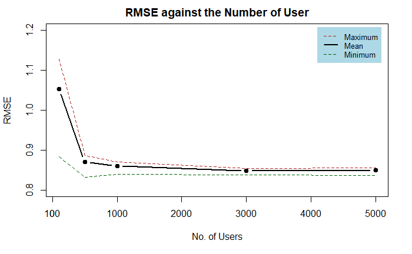

```r
# Add a legend
legend("topright", inset=.02, legend=c("Maximum", "Mean", "Minimum"), box.lty=0,
       col=c("firebrick", "black","darkgreen"), lty= c(2,1,2), lwd= c(1,2,1), cex=0.8, bg='lightblue')
```

It was decided to change the number of movies used. The sizes used were 500, 100 and 2000

```r
tic()
seed <- c(1,101,525,69, 73)

accuracy100users500movies <- sapply(1:5,function(i) Fulltest(Ratings, no_of_users = 100, no_of_movies = 500, seed = seed[i]))
accuracy500users500movies <- sapply(1:5,function(i) Fulltest(Ratings, no_of_users = 500, no_of_movies = 500, seed = seed[i]))
accuracy1000users500movies <- sapply(1:5,function(i) Fulltest(Ratings, no_of_users = 1000, no_of_movies = 500, seed = seed[i]))
accuracy3000users500movies <- sapply(1:5,function(i) Fulltest(Ratings, no_of_users = 3000, no_of_movies = 500, seed = seed[i]))
accuracy5000users500movies <- sapply(1:5,function(i) Fulltest(Ratings, no_of_users = 5000, no_of_movies = 500, seed = seed[i]))
toc()
```

Saving the results recorded so far

```r
save(accuracy100users1000movies, accuracy500users1000movies, accuracy1000users1000movies, accuracy3000users1000movies, accuracy5000users1000movies, accuracy100users500movies, accuracy500users500movies, accuracy1000users500movies, accuracy3000users500movies, accuracy5000users500movies, Range_for_1000movies,  file = "data/Results.RData")
load("data/Results.RData")
```

Plotting the results of using 500 movies

[figure not shown]

```r
x_axis = c(100, 500, 1000, 3000, 5000)
plot(x= x_axis, y = Range_for_500movies[4,], type = "b", pch = 19, ylim = c(0.8, 1.1), lwd = 2, ylab = "RMSE", xlab = "No. of Users", main = "RMSE against the Number of User for 500 movies")
lines(x= x_axis, y =Range_for_500movies[1,], col = "blue", lty = 2)
```

```r
lines(x= x_axis, y =Range_for_500movies[5,], col = "red", lty = 2)
axis(1, at = c(1, 2, 3, 4, 5) ,labels=colnames(Range_for_500movies))
```

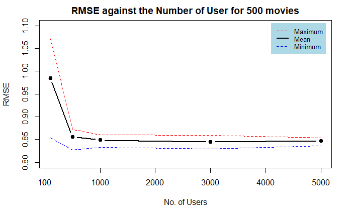

```r
# Add a legend
legend("topright", inset=.02, legend=c("Maximum", "Mean", "Minimum"), box.lty=0,
       col=c("red", "black","blue"), lty= c(2,1,2), lwd= c(1,2,1), cex=0.8, bg='lightblue')
```

Sampling users, with 100 movies

```r
tic()
seed <- c(1,101,525,69, 73)

accuracy100users100movies <- sapply(1:5,function(i) Fulltest(Ratings, no_of_users = 100, no_of_movies = 100, seed = seed[i]))
accuracy500users100movies <- sapply(1:5,function(i) Fulltest(Ratings, no_of_users = 500, no_of_movies = 100, seed = seed[i]))
accuracy1000users100movies <- sapply(1:5,function(i) Fulltest(Ratings, no_of_users = 1000, no_of_movies = 100, seed = seed[i]))
accuracy3000users100movies <- sapply(1:5,function(i) Fulltest(Ratings, no_of_users = 3000, no_of_movies = 100, seed = seed[i]))
accuracy5000users100movies <- sapply(1:5,function(i) Fulltest(Ratings, no_of_users = 5000, no_of_movies = 100, seed = seed[i]))
toc()
```

```r
Range_for_100movies <- cbind(summary(accuracy100users100movies),summary(accuracy500users100movies),summary(accuracy1000users100movies),summary(accuracy3000users100movies),summary(accuracy5000users100movies))
colnames(Range_for_100movies) <- c("100", "500", "1000", "3000", "5000")
boxplot(Range_for_100movies, xlab = "No of Users", col = c("blue", "red", "green", "violet" , "yellow" ))
```

[output not shown]

Sampling users, with 2000 movies

```r
seed <- c(1,101,525,69, 73)

accuracy100users2000movies <- sapply(1:5,function(i) Fulltest(Ratings, no_of_users = 100, no_of_movies = 2000, seed = seed[i]))
accuracy500users2000movies <- sapply(1:5,function(i) Fulltest(Ratings, no_of_users = 500, no_of_movies = 2000, seed = seed[i]))
accuracy1000users2000movies <- sapply(1:5,function(i) Fulltest(Ratings, no_of_users = 1000, no_of_movies = 2000, seed = seed[i]))
accuracy3000users2000movies <- sapply(1:5,function(i) Fulltest(Ratings, no_of_users = 3000, no_of_movies = 2000, seed = seed[i]))
accuracy5000users2000movies <- sapply(1:5,function(i) Fulltest(Ratings, no_of_users = 5000, no_of_movies = 2000, seed = seed[i]))
```

```r
Range_for_2000movies <- cbind(summary(accuracy100users2000movies),summary(accuracy500users2000movies),summary(accuracy1000users2000movies),summary(accuracy3000users2000movies),summary(accuracy5000users2000movies))
colnames(Range_for_2000movies) <- c("100", "500", "1000", "3000", "5000")
boxplot(Range_for_2000movies, xlab = "No of Users", col = c("blue", "red", "green", "violet" , "yellow" ))
```

[output not shown]

```r
x_axis = c(100, 500, 1000, 3000, 5000)
plot(x= x_axis, y = Range_for_2000movies[4,], type = "b", pch = 19, ylim = c(0.82, 1.5), lwd = 2, ylab = "RMSE", xlab = "No. of Users", main = "RMSE against the Number of User for 2000 movies")
lines(x= x_axis, y =Range_for_2000movies[1,], col = "blue", lty = 2)
lines(x= x_axis, y =Range_for_2000movies[5,], col = "red", lty = 2)
axis(1, at = c(1, 2, 3, 4, 5) ,labels=colnames(Range_for_2000movies))
# Add a legend
legend("topright", inset=.02, legend=c("Maximum", "Mean", "Minimum"), box.lty=0,
       col=c("red", "black","blue"), lty= c(2,1,2), lwd= c(1,2,1), cex=0.8, bg='lightblue')
```

[output not shown]

Checking the progression of the RMSE with respect to the number of movies sampled.The number of movies sampled were 100, 500, 1000 and 2000.

```r
RMSE_vs_Movies <- cbind(Range_for_100movies[4,], Range_for_500movies[4,] ,Range_for_1000movies[4,], Range_for_2000movies[4,])
RMSE_vs_Movies
```

```
          [,1]      [,2]      [,3]      [,4]
100  0.9063288 0.9854130 1.0530934 1.3413817
500  0.8575332 0.8562578 0.8697713 0.8785680
1000 0.8619128 0.8488421 0.8601217 0.8627051
3000 0.8520830 0.8447770 0.8483023 0.8508014
5000 0.8570698 0.8468344 0.8493020 0.8505138
```

```r
colindex = c("blue", "red", "green", "violet")

#plot of all the different user sizes
plot(x = c(100, 500, 1000, 2000), y = RMSE_vs_Movies[5,], type = "l", ylim = c(0.83,1.5), col = "yellow", main = "RMSE against the Number of Movies", xlab = "Number of Movies", ylab = "RMSE")
for (i in 1:4) {
  lines(x = c(100, 500, 1000, 2000), y = RMSE_vs_Movies[i,], col = colindex[i] )
}
```

[figure not shown]

```r
legend("topleft", inset=.02, legend=c("100 users","500 users","1000 users","3000 users","5000 users"), box.lty=1,
       col=c(colindex, "yellow"), lty= 1, cex=0.8)
```

```r
#plot of all the different user sizes excluding 100 users for a closer look
plot(x = c(100, 500, 1000, 2000), y = RMSE_vs_Movies[5,], type = "l", ylim = c(0.83,0.9), xlim = c(100,2000), col = "yellow", main = "RMSE against the Number of Movies", xlab = "Number of Movies", ylab = "RMSE")
for (i in 2:4) {
  lines(x = c(100, 500, 1000, 2000), y = RMSE_vs_Movies[i,], col = colindex[i] )
}
```

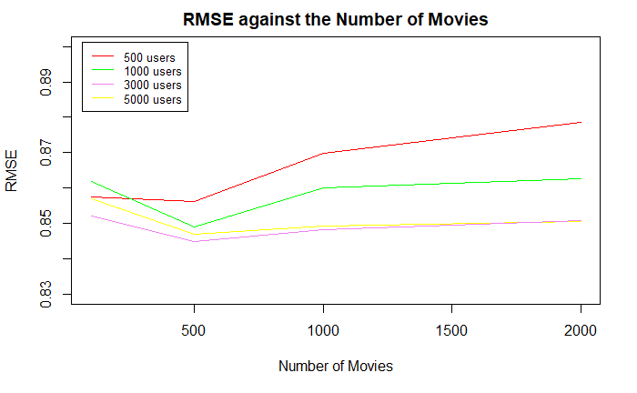

```r
legend("topleft", inset=.02, legend=c("500 users","1000 users","3000 users","5000 users"), box.lty=1,
       col=c(colindex[2:4], "yellow"), lty= 1, cex=0.8)
```

Full prediction of all movies

```r
#editing the matrix factorization formula
MF_Prediction <- function(Movie_rating){
  #Movie_rating - the spread data matrix of movie ratings

  #H0 and W0 are the bias matrices, that are set to an initial value of 1.
init = list(
  H0 = matrix(1, nrow = 1, ncol = ncol(Movie_rating)),
  W0 = matrix(1, nrow = nrow(Movie_rating), ncol = 1)
)

# matrix factorization with bias included
decomp <- nnmf(A = Movie_rating,
               method = "scd",       #decomposition method is sequential coordinate-wise descent
               k = 3,
               alpha = c(0.001,0,0),  #L2 Regularisation on W
               beta = c(0.001,0,0),   #L2 Regularisation on H
               init = init, # bias terms
               max.iter = 10000) #Maximum number of iterations

# results
MF_Predicted <- decomp$W %*% decomp$H  #predicted values of all the movie & user combinations
ifelse(MF_Predicted < 1, 1, MF_Predicted)
ifelse(MF_Predicted > 5, 5, MF_Predicted)

return(MF_Predicted)
}

Fullprediction <- function(seed, no_of_users, data, no_of_movies){
  #seed - set seed to ensure reproducibility
  #no_of_users - scalar value, the number of users to be sampled at random from the full dataset
  #no_of_movies - scalar value, the number of movies to sample. The movies shall be sampled in descending order to gain as much information as possible
  #data - the dataframe of the movie ratings

  Reduced_Ratings <- Data_Subset(data, no_of_users, no_of_movies, seed)

  #No need for a test set split

  #spreading the ratings into a wide matrix of users and movies
  Movie_rating <- Reduced_Ratings %>%
    complete(userId, title) %>%
    select(userId, title, rating) %>%
    spread(key = title, value = rating)

  sorted_users <- as.character(unlist(Movie_rating[,1]))
  Movie_rating <- as.matrix(Movie_rating[,-1])   #removing the first column of userId
  row.names(Movie_rating) <- sorted_users  #labeling the with the userId

  user_sim <- cosine_sim(Movie_rating)


  #User-based filtering method
  FullPredictionA <- matrix(0, nrow = nrow(Movie_rating), ncol = ncol(Movie_rating))

  for (i in 1:nrow(Movie_rating)){
    for ( j in 1:ncol(Movie_rating)){

      sim <- user_sim[i,]
      rate <- Movie_rating[,j]

      sim_to_user <- as.data.frame(na.omit(cbind(sim, rate)))
      scaled_sim <- sim_to_user$sim/sum(sim_to_user$sim)
      sim_to_user <- cbind(sim_to_user,scaled_sim)
      FullPredictionA[i,j] <- crossprod(sim_to_user$rate,scaled_sim)
      FullPredictionA[i,j] <- ifelse(is.nan(FullPredictionA[i,j]) == T, mean(sim_to_user$rate), FullPredictionA[i,j])
    }
  }

  #Item-based filtering method
  movies_user <- t(Movie_rating)  #transpose the Movie_rating matrix to be used to calculate the similarity between movies
  movie_sim <- cosine_sim(movies_user) #cosine similarity of movies

  FullPredictionB <- matrix(0, nrow = nrow(movies_user), ncol = ncol(movies_user))

  for (i in 1:nrow(movies_user)){
    for ( j in 1:ncol(movies_user)){

      sim <- movie_sim[i,]
      rate <- movies_user[,j]

      sim_to_movie <- as.data.frame(na.omit(cbind(sim, rate)))
      scaled_movie_sim <- sim_to_movie$sim/sum(sim_to_movie$sim)
      sim_to_movie <- cbind(sim_to_movie,scaled_movie_sim)
      FullPredictionB[i,j] <- crossprod(sim_to_movie$rate,scaled_movie_sim)
      FullPredictionB[i,j] <- ifelse(is.nan(FullPredictionB[i,j]) == T, mean(sim_to_movie$rate), FullPredictionB[i,j])
    }
  }
  FullPredictionB <- t(FullPredictionB)

  #Matrix Factorization Method
  FullPredictionC <- MF_Prediction(Movie_rating)

  #Ensemble Predictions
  FullPredictionD <- (FullPredictionA + FullPredictionBB + FullPredictionC)/3

  return(FullPredictionD)
}
```

An example of how the model would work

```r
tic()
Fullprediction(seed = 25, no_of_users = 10, no_of_movies = 10, data = Ratings)
toc()
```